# Facets

PH345: Winter 2026

Philip Boonstra

## Horse in Motion

[figure not shown]

Is there a moment where a galloping horse has all hooves off the ground?

Eadweard Muybridge, 1878. Public Domain

## Chromosomes

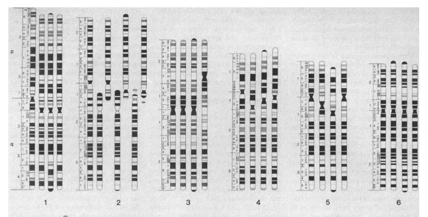

> Schematic representation of late-prophase chromosomes (1000-band stage) of man, chimpanzee, gorilla, and orangutan, arranged from left to right, respectively, to better visualize homology between the chromosomes of the great apes and the human complement.

Figure 2, Yunis and Prakash (1982)

## What is this called?

> [S]lice the data into parts according to one or more data dimensions, visualize each data slice separately, and then arrange the individual visualizations into a grid (Ch21, Wilke, 2019).

Called ‘small multiples’ (Tufte, 1991), ‘trellis plots’ (Becker et al., 1996), or ‘facet plots’ (Wickham, 2016).

## Why do this?

Introduces a third dimension (first two dimensions being x and y). Essentially another aesthetic.

Tufte’s principles of graphical excellence:

- *Present many numbers in small space*
- *Make large data sets coherent*

## What are guidelines?

Useful when focus is more on individual observations than on overall trends and to see how differences vary between observations

Faceting variable must be categorical

Each mini-plot should (normally) have same structure: common axes, scales, etc

## Hadley Wickham (1979-)

New Zealand statistician, Chief Scientist at Posit PBC

Creator of `ggplot2` and the `tidyverse`

John Chambers Award for Statistical Computing (2006); Fellow of ASA (2015); COPSS Presidents’ Award (2019)

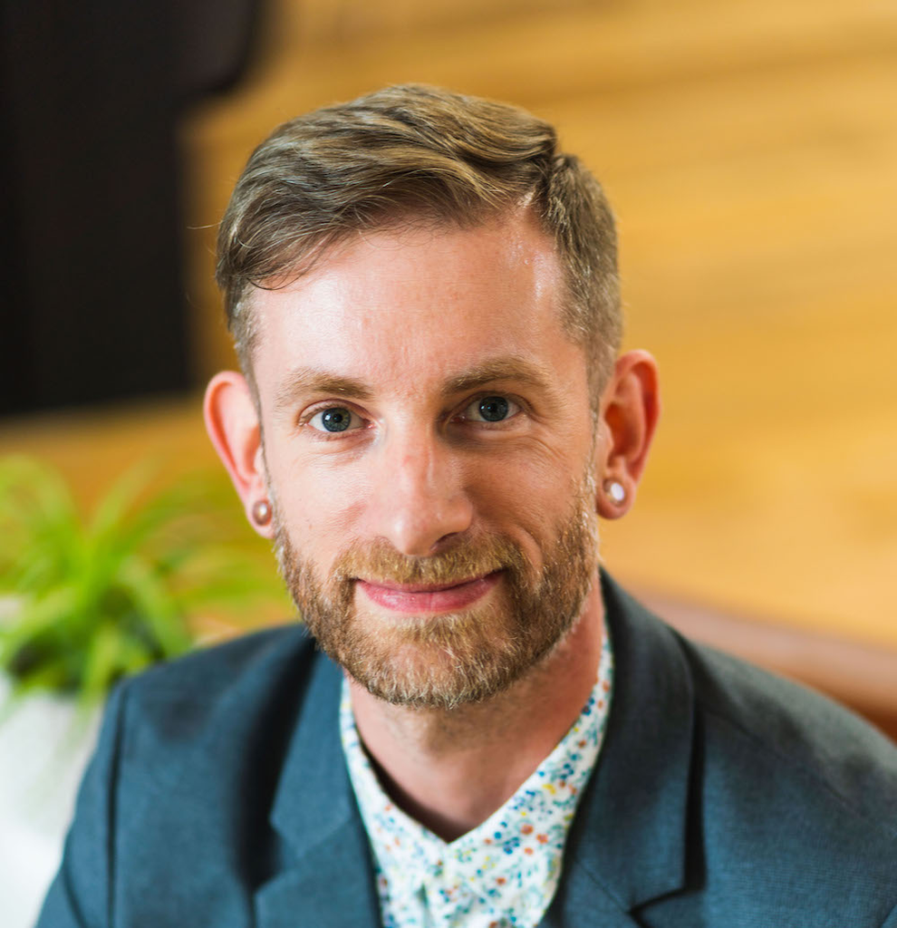

https://hadley.nz/

## Two flavors of faceting in `ggplot2`

1. `facet_wrap()`: wrap a 1D ribbon of plots into 2D grid
2. `facet_grid()`: create a 2D grid of plots

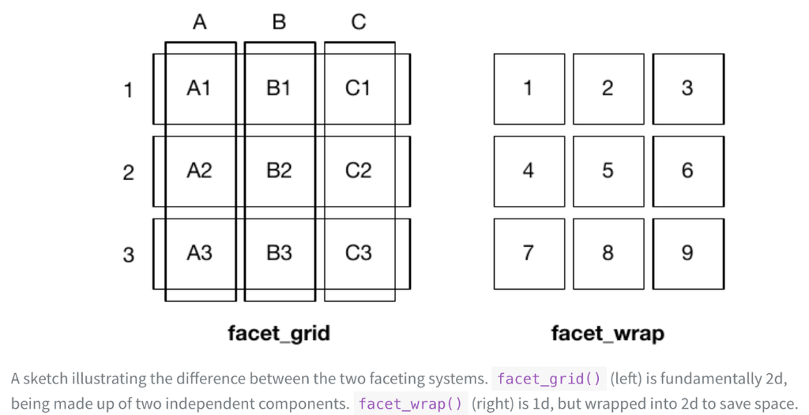

See Chapter 16 of `ggplot2` book (https://ggplot2-book.org/facet)

## We’ve already seen `facet_wrap()`

- Plot
- Code

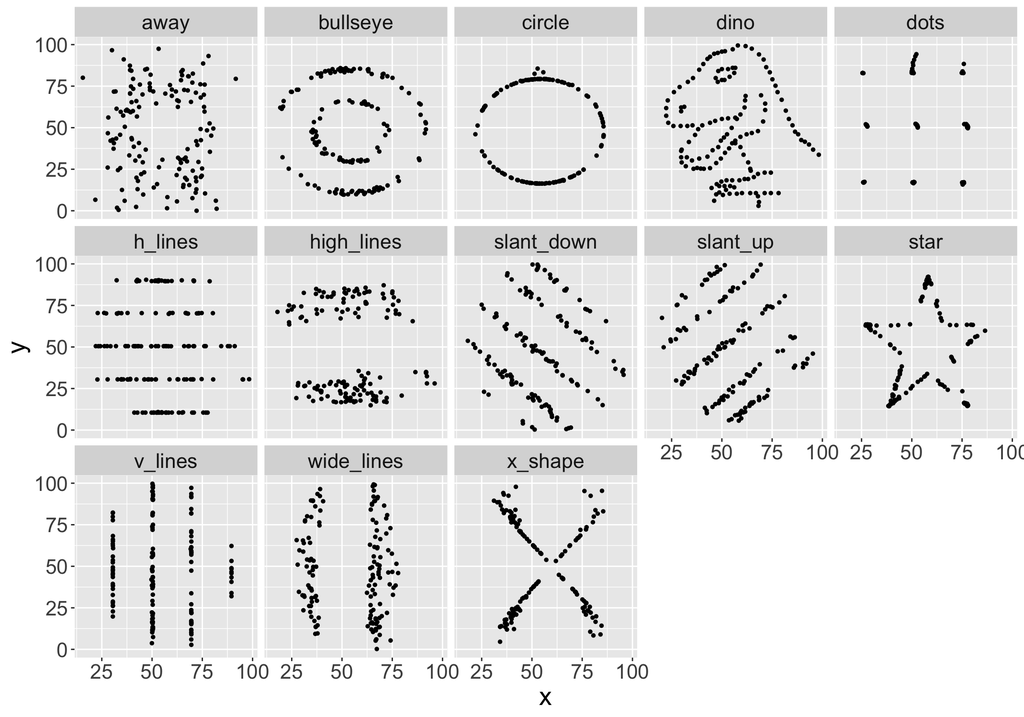

```r
# Install and load datasauRus if not already installed
if(!require(datasauRus)) {install.packages("datasauRus");library(datasauRus)}
ggplot(datasaurus_dozen) +
  geom_point(aes(x = x, y = y), size = 1) +
  facet_wrap(facets = vars(dataset), ncol = 5) +
  guides(color = "none") +
  theme(text = element_text(size = 20))
```

#### `facet_grid()` doesn’t ‘work’ here

Aspect ratio (ratio of height and width) needs to be maintained

- Plot
- Code

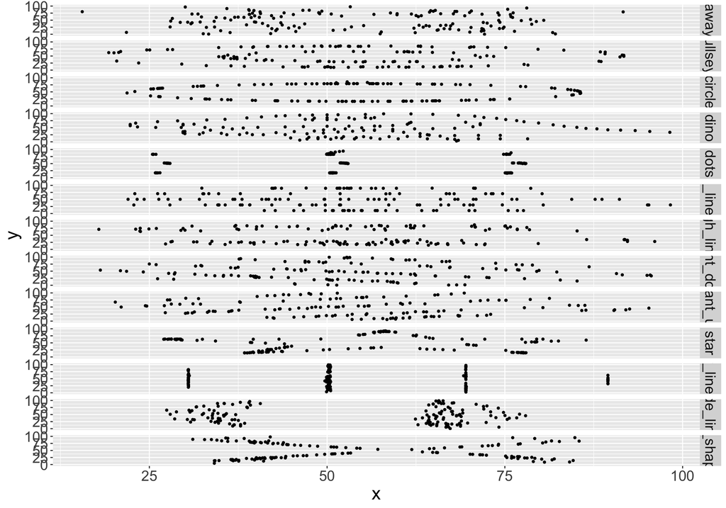

```r
# Install and load datasauRus if not already installed
if(!require(datasauRus)) {install.packages("datasauRus");library(datasauRus)}
ggplot(datasaurus_dozen) +
  geom_point(aes(x = x, y = y), size = 1) +
  facet_grid(rows = vars(dataset)) +
  guides(color = "none") +
  theme(text = element_text(size = 20))
```

#### Doesn’t work as columns either

- Plot
- Code

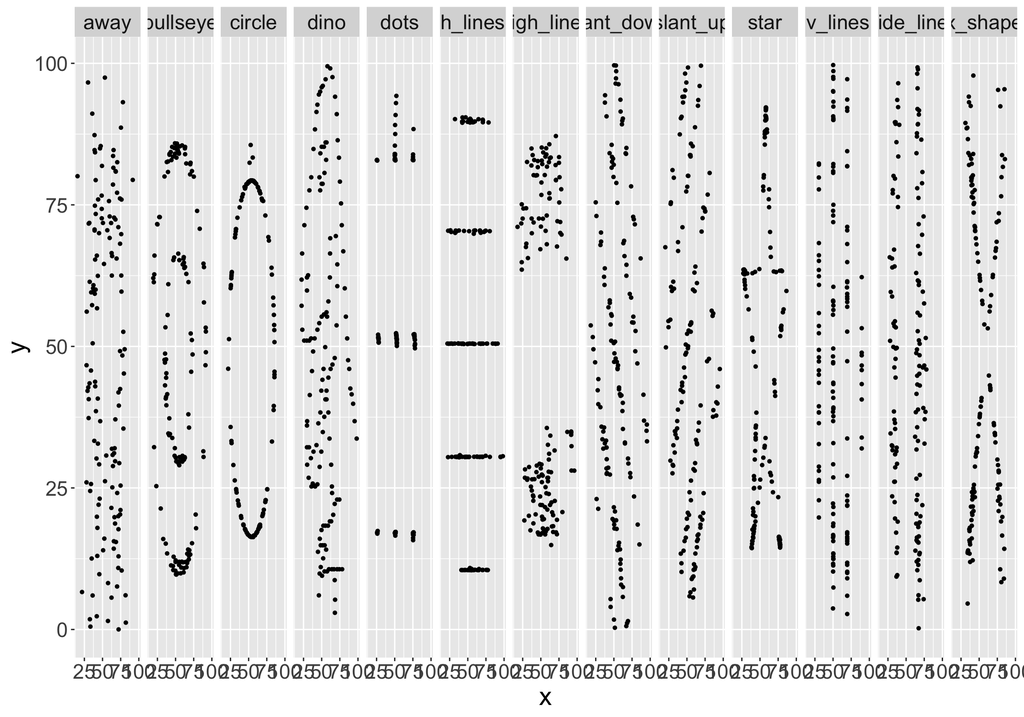

```r
# Install and load datasauRus if not already installed
ggplot(datasaurus_dozen) +
  geom_point(aes(x = x, y = y), size = 1) +
  facet_grid(cols = vars(dataset)) +
  guides(color = "none") +
  theme(text = element_text(size = 20))
```

## Unemployment in USA

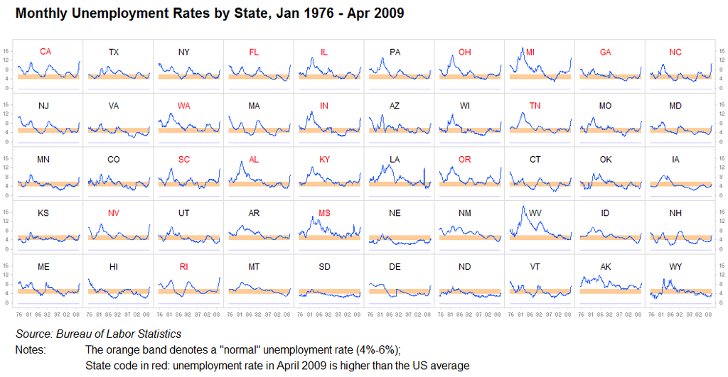

Jorge Camoes, https://excelcharts.com/charts-monthly-unemployment-rates-by-state-1976-2009/

Wrapped facet by US States, ordered by size of workforce. Easy to compare trends across states. Unemployment band provides anchors

## Life expectancy in USA

[figure not shown]

Anna Maria Barry-Jester, https://fivethirtyeight.com/features/as-u-s-life-expectancies-climb-people-in-a-few-places-are-dying-younger/

Sort of a facet grid by categorized latitude and longtitude. The trend line provides an anchor. The amount of purple and orange allow to immediately determine the relationship with nationwide changes in life expectancy

## Malaria

- Spread by the bite of female *Anopheles* mosquitos, which are hosts to the malaria parasite
- Exists in tropical and subtropical regions with inadequate public health infrastructure
- 263 million cases in 2023; 597,000 deaths

US CDC: https://www.cdc.gov/malaria/data-research/index.html;

World Malaria Report, WHO: https://www.who.int/teams/global-malaria-programme/reports/world-malaria-report-2024

## Global malaria incidence

WHO collects country-level data on malaria incidence.

Raw data on incidence per 1000-at risk persons available at https://data.worldbank.org/indicator/SH.MLR.INCD.P3

Friendlier data available on canvas (`malaria_countries_long.csv`)

#### An unfaceted plot of incidence: Sub-Saharan Africa

- Plot
- Code

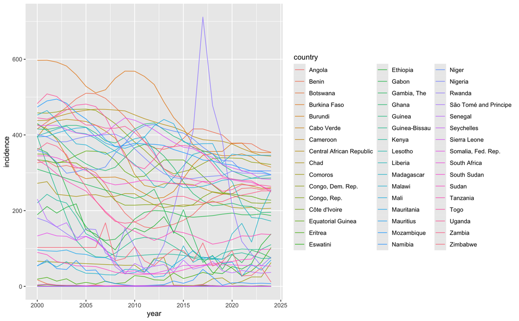

```r
# I've downloaded the data from Canvas into my project folder:
malaria_countries <- read_csv("malaria_countries_long.csv")
malaria_countries_ssafrica <- malaria_countries %>% filter(region == "Sub-Saharan Africa")
```

```r
ggplot(malaria_countries_ssafrica) +
  geom_line(aes(x = year, y = incidence, group = country, color = country),
            alpha = 0.75)
```

#### An faceted plot of incidence: Sub-Saharan Africa

- Plot
- Code

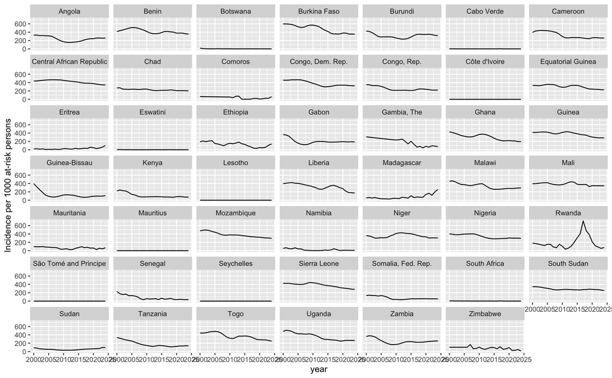

```r
# Create ggplot object for future updating
p1 <-
  ggplot(data = malaria_countries_ssafrica,
         mapping = aes(x = year, y = incidence)) +
    geom_line() +
    facet_wrap(vars(country)) +
    scale_y_continuous(name = "Incidence per 1000 at-risk persons")

p1
```

#### Drop the ‘strips’

- Plot
- Hint
- Code

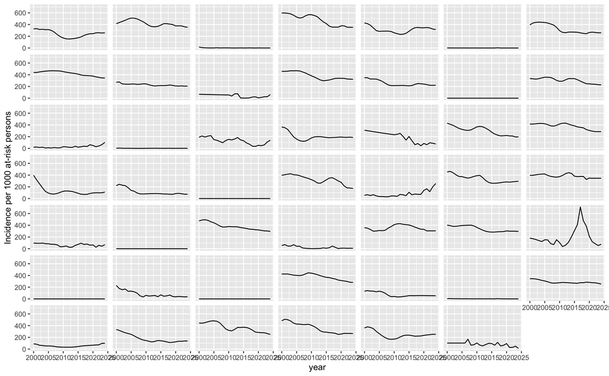

```r
# To drop the strips completely, add this to your code:
theme(strip.text = element_blank())
```

```r
# Update p1 object from previous slide with the provided hints
p2 <-
  p1 + theme(strip.text = element_blank())
p2
```

#### Add labels inside

- Plot
- Hint
- Code

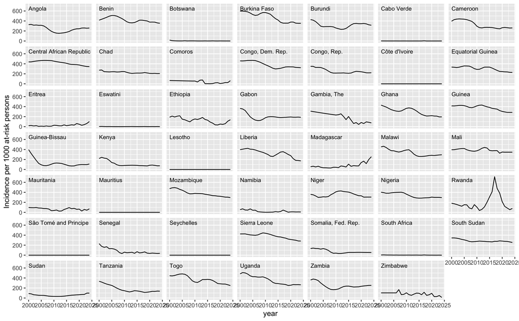

```r
# To add labels to the plots, use a dataset with just one row per country:
malaria_countries_ssafrica %>%
  group_by(country) %>%
  slice(1)
```

```r
# Update p1 object from previous slide with the provided hints
p3 <-
  p2 +
    # The '.' means we are taking the data inherited from the p2 object
    # and further modifying it
    geom_text(data = . %>% group_by(country) %>% slice(1),
              aes(label = country), x = 2000, y = 650, hjust = 0, size = 3)+
    theme(strip.text = element_blank())
p3
```

- Plot
- Hint
- Code

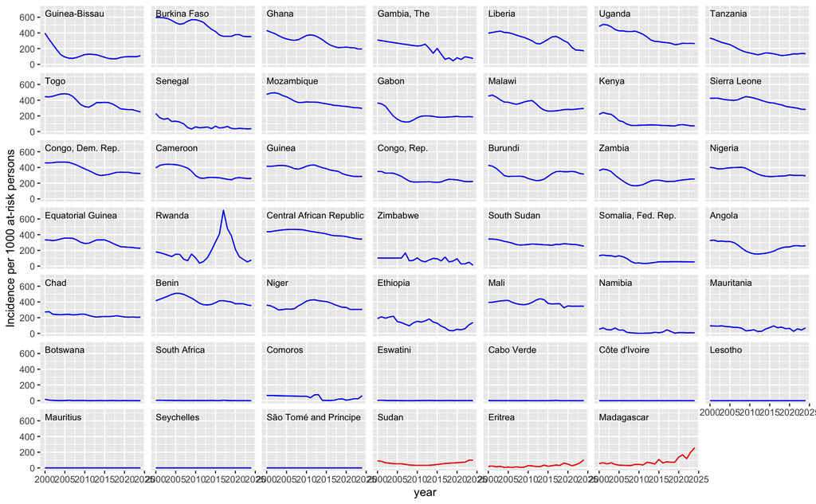

```r
# Create a new variable called delta_incidence that is the difference
# between the last and first incidence values for each country.
# Then arrange the data by this variable and turn country into a factor
# with levels in the order that they appear in the data:

mutate(country = factor(country) %>% fct_inorder())
```

```r
malaria_countries_ssafrica2 <-
  malaria_countries_ssafrica %>%
  group_by(country) %>%
  # Note we are using mutate not summarize since we want to keep the year-level
  # data. Because the data are grouped by `Country Code`, the result will just
  # be constant within country
  mutate(delta_incidence = last(incidence) - first(incidence)) %>%
  ungroup() %>%
  # Now sort by the calculated value, then country name, then year
  arrange(delta_incidence, country, year) %>%
  # Now we recharacterize Country name as a factor with levels as they
  # are arranged
  mutate(country = factor(country) %>% fct_inorder())

# update p3 object from previous slide with new data
# Note use of new operator `%+%` for updating data. Type ?'%+%' for more information; basically this is a shortcut for rerunning the
# code in p3 but with a new dataset. This is useful since we have a lot of code in p3 that we don't want to repeat.
p4 <- p3 %+% malaria_countries_ssafrica2 +
  geom_line(aes(color = delta_incidence > 0)) +
  scale_color_manual(values = c("blue", "red")) +
  guides(color = "none")

p4
```

#### Anchor all panels with the Sub-Saharan-wide trajectory

- Plot
- Code
- Code (Stand alone)

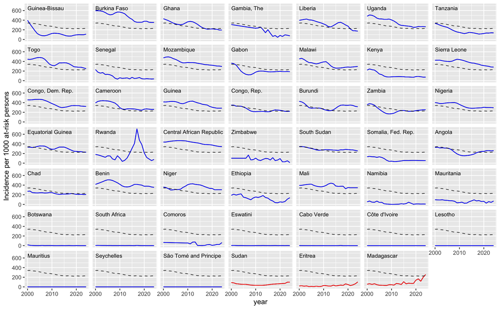

```r
# I've downloaded the data from Canvas into my project folder:
malaria_all_ssafrica <- read_csv("malaria_other_long.csv") %>% filter(name == "Sub-Saharan Africa")
```

```r
p4 +
  geom_line(data = malaria_all_ssafrica,
            linetype = "dashed", alpha = 0.75) +
  scale_x_continuous(breaks = c(2000, 2010, 2020))
```

```r
# This is a complete, stand-alone version to make the same plot

malaria_countries <- read_csv("malaria_countries_long.csv")
malaria_countries_ssafrica <- malaria_countries %>% filter(region == "Sub-Saharan Africa")

malaria_countries_ssafrica2 <-
  malaria_countries_ssafrica %>%
  group_by(country) %>%
  # Note we are using mutate not summarize since we want to keep the year-level
  # data. Because the data are grouped by `Country Code`, the result will just
  # be constant within country
  mutate(delta_incidence = last(incidence) - first(incidence)) %>%
  ungroup() %>%
  # Now sort by the calculated value, then country name, then year
  arrange(delta_incidence, country, year) %>%
  # Now we recharacterize Country name as a factor with levels as they
  # are arranged
  mutate(country = factor(country) %>% fct_inorder())

# I've downloaded the data from Canvas into my project folder:
malaria_all_ssafrica <- read_csv("malaria_other_long.csv") %>% filter(name == "Sub-Saharan Africa")

ggplot(data = malaria_countries_ssafrica2,
       mapping = aes(x = year, y = incidence)) +
  geom_line(aes(color = delta_incidence > 0)) +
  geom_text(data = . %>% group_by(country) %>% slice(1),
            aes(label = country), x = 2000, y = 650, hjust = 0, size = 3) +
  geom_line(data = malaria_all_ssafrica,
            linetype = "dashed", alpha = 0.75) +
  facet_wrap(vars(country)) +
  scale_x_continuous(breaks = c(2000, 2010, 2020)) +
  scale_y_continuous(name = "Incidence per 1000 at-risk persons") +
  scale_color_manual(values = c("blue", "red")) +
  guides(color = "none") +
  theme(strip.text = element_blank())
```

#### An example with varying y-axes

- Plot
- Hint
- Code

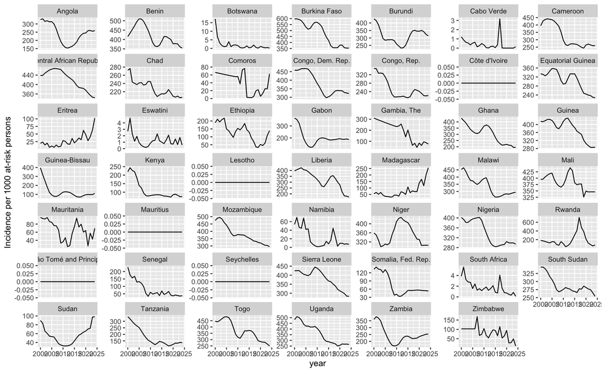

```r
ggplot(data = malaria_countries_ssafrica,
       mapping = aes(x = year, y = incidence)) +
  geom_line() +
  facet_wrap(vars(country), scales = "free_y") +
  scale_y_continuous(name = "Incidence per 1000 at-risk persons")
```

Think about differences between choice of varying y-axes: Varying y-axes are essentially many individual plots. Varying y-axes make it easier to evaluate differences within a panel but harder to compare between panels

## Code Together Task

**No Spice**: Make the standard faceted plot on slide 17;

**Weak Sauce**: Make the faceted plot without strips on slide 18; Make the faceted plot with varying y-axes on slide 22;

**Medium Spice**: Make the faceted plot with inside labels on slide 19

**Yoga Flame**: Make the faceted plot with reordered facets on slide 20

**Dim Mak**: Make the faceted plot with the Sub-Saharan Africa trajectory on slide 21

## References

Becker, R.A., Cleveland, W.S. and Shyu, M.J., 1996. *The visual design and control of trellis display*. Journal of computational and Graphical Statistics, 5(2), pp.123-155.

Tufte, E.R., 1991. Envisioning information. Optometry and Vision Science, 68(4), pp.322-324.

Wickham H (2016). ggplot2: Elegant Graphics for Data Analysis. Springer-Verlag New York. ISBN 978-3-319-24277-4, https://ggplot2.tidyverse.org.

Wilke, C.O., 2019. Fundamentals of data visualization: a primer on making informative and compelling figures. O’Reilly Media.

Yunis, J.J. and Prakash, O., 1982. *The origin of man: a chromosomal pictorial legacy.* Science, 215(4539), pp.1525-1530.